# PK2: Two-Compartment Oral PK — Parameter Sensitivity Exploration

Ruoqi Deng

June 2026

# 1 Background and goals

The previous project in this portfolio (`02_pk1_oral_one_compartment/`) worked with the simplest pharmacologically meaningful structure: a one-compartment model with first-order oral absorption and first-order elimination. By perturbing `KA`, `CL`, and `V` one at a time, that project built intuition for how each parameter reshapes the concentration-time curve, and surfaced one counterintuitive result (doubling `V` raised the amount in the central compartment while lowering plasma concentration).

This project adds one structural element: a **peripheral compartment**. The drug now has somewhere else to go besides being cleared. That single addition introduces two new parameters and one qualitatively new phenomenon.

The model is `pk2` from `mrgsolve`’s built-in model library. Relative to `pk1` it adds:

- `PERIPH` — a peripheral compartment (mg) representing tissues whose drug concentration lags behind plasma.
- `Q` — inter-compartmental clearance (L/h), governing how fast drug exchanges between central and peripheral compartments.
- `V3` — peripheral volume of distribution (L).

The parameters carried over from `pk1` keep almost the same names (`CL`, `KA`), with the one-compartment `V` now written `V2` for the central volume. This continuity is deliberate: setting `Q` to zero should recover `pk1` exactly, and one of the experiments below tests precisely that.

The qualitatively new phenomenon is the **distribution phase**: an initial rapid decline after the peak, followed by a slower terminal decline, visible as a change in slope (“kink”) on a semi-log plot of `CP` versus time.

## 1.1 What this document does

Six experiments, organized as two groups. The first four isolate the two new parameters (`Q` and `V3`) and the structural behavior they produce. The last two are control experiments that confirm the basic properties established in `pk1` survive the move to two compartments.

1. **Baseline simulation** — single 100 mg dose, 72 h horizon.
2. **Experiment 1: Double `Q`** — faster inter-compartmental exchange.
3. **Experiment 2: Double `V3`** — larger peripheral compartment. *My prediction for this one was wrong, and working out why is where most of the value of this project sits.*
4. **Experiment 3: `Q` toward 0** — does `pk2` degenerate to `pk1`?
5. **Experiment 4: `Q` toward infinity** — the rapid-equilibrium limit.
6. **Experiment 5: Double the dose** — dose-proportional scaling.
7. **Experiment 6: Multiple dosing (Q12h x 5)** — accumulation, and a comparison against the one-compartment case.

# 2 Model

## 2.1 Equations

The two-compartment oral model is governed by three ODEs:

$$\begin{aligned}
\frac{dA_{EV}}{dt} &= -K_A \cdot A_{EV} \\
\frac{dA_{CENT}}{dt} &= K_A \cdot A_{EV}
- \frac{CL}{V_2} \cdot A_{CENT}
- \frac{Q}{V_2} \cdot A_{CENT}
+ \frac{Q}{V_3} \cdot A_{PERIPH} \\
\frac{dA_{PERIPH}}{dt} &= \frac{Q}{V_2} \cdot A_{CENT}
- \frac{Q}{V_3} \cdot A_{PERIPH}
\end{aligned}$$

with plasma concentration

$$CP(t) = \frac{A_{CENT}(t)}{V_2}.$$

The four terms in the central-compartment equation are, in order: absorption from the depot, elimination by clearance, transfer out to the peripheral compartment, and return from the peripheral compartment. The structure is

$$EV \xrightarrow{K_A} CENT
\underset{Q/V_3}{\overset{Q/V_2}{\rightleftharpoons}} PERIPH,
\qquad CENT \xrightarrow{CL/V_2} \text{(cleared)}.$$

Two points worth noting before any simulation, because they explain most of what follows:

- `V3` never appears in the definition of `CP`. Its only entry into the system is through the combination `Q/V3` in the exchange terms. Any effect of `V3` on plasma concentration is therefore entirely indirect, routed through the peripheral compartment.
- `Q` and `V3` always appear as the ratios `Q/V2` and `Q/V3`, which are rate constants (1/h). The same flow `Q` produces a faster turnover in the smaller compartment.

## 2.2 Setup

```r
library(mrgsolve)
library(dplyr)
library(ggplot2)
library(tidyr)
```

Load the built-in `pk2` model:

```r
mod <- modlib("pk2")
mod
```

```
##
##
## -----------------  source: pk2.cpp  -----------------
##
##   project: D:/R-4.5.2/libra...gsolve/models
##   shared object: pk2-so-80c8736a4bce
##
##   time:          start: 0 end: 24 delta: 1
##                  add: <none>
##   compartments:  EV CENT PERIPH [3]
##   parameters:    CL V2 Q V3 KA [5]
##   captures:      CP [1]
##   omega:         0x0
##   sigma:         0x0
##
##   solver:        rtol: 1e-08 atol: 1e-08 itol: 1 (scalar)
## ------------------------------------------------------
```

Check default parameter values:

```r
param(mod)
```

```
##
##  Model parameters (N=5):
##  name value . name value
##  CL   1     | V2   20
##  KA   1     | V3   10
##  Q    2     | .    .
```

Defaults: `CL = 1`, `V2 = 20`, `Q = 2`, `V3 = 10`, `KA = 1`. Note that `CL`, `V2`, and `KA` match the `pk1` defaults exactly, which is what makes the `Q -> 0` degeneration test in Experiment 3 a clean comparison.

Helper functions used throughout:

```r
# Run a single-dose simulation under a given parameter set, return a tidy frame
run_single_dose <- function(model, dose = 100, end = 72, delta = 0.1) {
  model %>%
    ev(amt = dose) %>%
    mrgsim(end = end, delta = delta) %>%
    as.data.frame()
}

# Tag each simulation with a label, for overlay plotting
label_run <- function(df, label) {
  df %>% mutate(scenario = label)
}

# Estimate terminal half-life by log-linear regression on the tail
terminal_thalf <- function(df, t_min = 40) {
  d <- df %>% filter(time >= t_min, CP > 0)
  fit <- lm(log(CP) ~ time, data = d)
  lambda <- -coef(fit)[["time"]]
  log(2) / lambda
}

# AUC by linear trapezoidal rule (to Clast)
auc_trap <- function(df) {
  d <- df %>% filter(CP > 0)
  sum(diff(d$time) * (head(d$CP, -1) + tail(d$CP, -1)) / 2)
}
```

# 3 Baseline simulation

A single 100 mg oral dose, simulated over 72 hours.

```r
out_baseline <- run_single_dose(mod, dose = 100)
head(out_baseline)
```

```
##   ID time        EV      CENT     PERIPH        CP
## 1  1  0.0   0.00000  0.000000 0.00000000 0.0000000
## 2  1  0.0 100.00000  0.000000 0.00000000 0.0000000
## 3  1  0.1  90.48374  9.444382 0.04780971 0.4722191
## 4  1  0.2  81.87308 17.851273 0.18293635 0.8925637
## 5  1  0.3  74.08182 25.323260 0.39389717 1.2661630
## 6  1  0.4  67.03200 31.953048 0.67040259 1.5976524
```

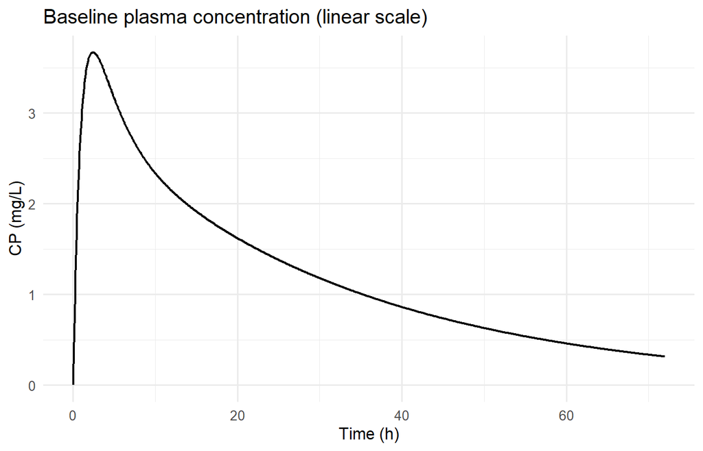

Figure 1. Baseline single-dose simulation, linear scale.

```r
ggplot(out_baseline, aes(x = time, y = CP)) +
  geom_line(linewidth = 0.8) +
  labs(
    title = "Baseline plasma concentration (linear scale)",
    x = "Time (h)", y = "CP (mg/L)"
  ) +
  theme_minimal(base_size = 12)
```

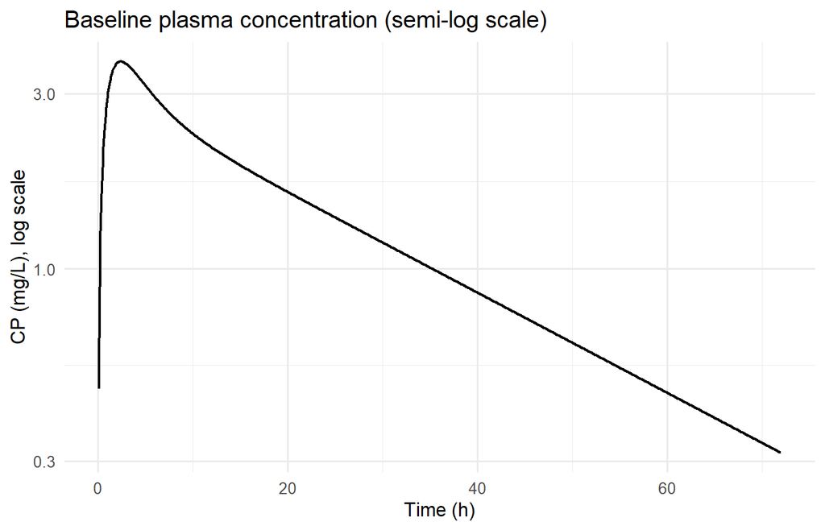

Figure 2. Baseline single-dose simulation, semi-log scale. The change in slope around 10 h marks the transition from distribution phase to elimination phase.

```r
out_baseline %>%
  filter(CP > 0) %>%
  ggplot(aes(x = time, y = CP)) +
  geom_line(linewidth = 0.8) +
  scale_y_log10() +
  labs(
    title = "Baseline plasma concentration (semi-log scale)",
    x = "Time (h)", y = "CP (mg/L), log scale"
  ) +
  theme_minimal(base_size = 12)
```

**What I see:** The concentration-time profile divides cleanly into three phases. During the absorption phase (0 to ~3 h), drug transfers from the extravascular depot into the central compartment at rate KA, and CP rises steeply as absorption dominates both elimination and distribution. During the distribution phase (~3 to ~10 h), drug flows out of the central compartment into the peripheral compartment faster than it returns; this net transfer to the periphery produces a rapid decline in CP. During the elimination phase (after ~10 h), the central and peripheral compartments approach quasi-equilibrium: drug still exchanges between them, but the net inter-compartmental flow is small compared to the rate at which CL removes drug from the system, so the entire system declines together, producing a single straight line on the semi-log scale.

On the linear scale, the curve looks almost indistinguishable from the one-compartment profile produced by pk1. Only on the semi-log scale does the slope change around 10 h become visible. I can see why semi-log plots are the standard first tool for identifying multi-compartment kinetics in pharmacometric practice.

To make the distribution phase directly visible, rather than inferring it from the slope of the CP curve, the next plot overlays the drug amounts in the central and peripheral compartments.

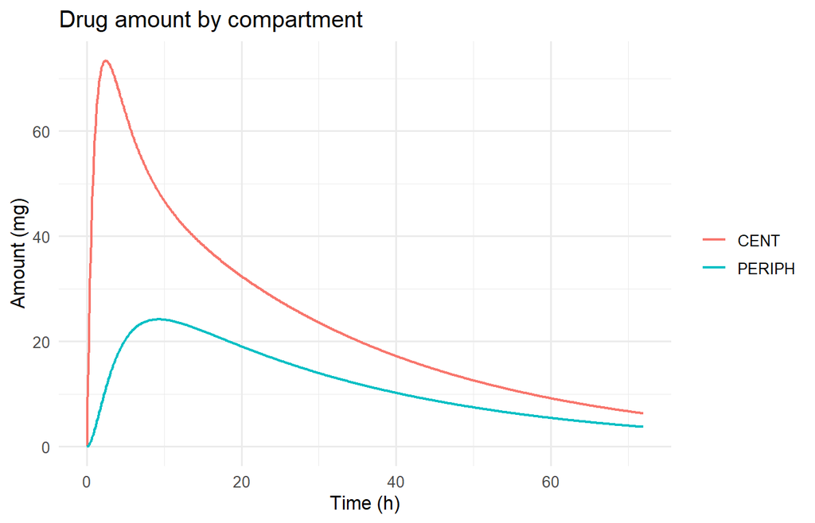

Figure 3. Amounts in the central and peripheral compartments. The peripheral compartment fills with a lag, then declines in parallel with central once quasi-equilibrium is reached.

```r
out_baseline %>%
  select(time, CENT, PERIPH) %>%
  pivot_longer(cols = c(CENT, PERIPH),
               names_to = "compartment", values_to = "amount") %>%
  ggplot(aes(x = time, y = amount, color = compartment)) +
  geom_line(linewidth = 0.8) +
  labs(
    title = "Drug amount by compartment",
    x = "Time (h)", y = "Amount (mg)", color = NULL
  ) +
  theme_minimal(base_size = 12)
```

**What I see:** The peripheral compartment fills with a clear lag behind the central compartment, then the two amounts converge toward quasi-equilibrium, after which they decline together. The moment that quasi-equilibrium is established corresponds to the change in slope seen around 10 h in Figure 2.

# 4 Single-parameter perturbations

For each experiment, the perturbed curve is overlaid on the baseline so the shift can be read directly. Semi-log scale is used wherever the distribution phase is the point of interest, since the change in slope is only legible there.

## 4.1 Experiment 1: Double `Q` (faster inter-compartmental exchange)

```r
out_q <- mod %>% param(Q = 4) %>% run_single_dose(dose = 100)

sim_exp1 <- bind_rows(
  label_run(out_baseline, "Baseline (Q = 2)"),
  label_run(out_q,        "Q doubled (Q = 4)")
)
```

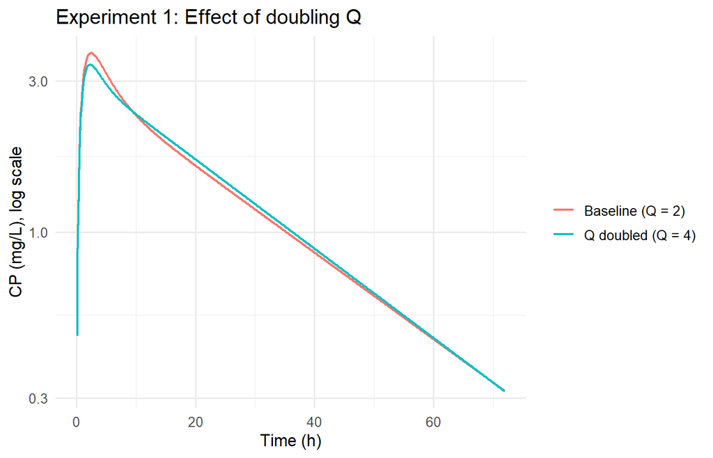

Figure 4. Doubling Q on semi-log scale.

```r
sim_exp1 %>%
  filter(CP > 0) %>%
  ggplot(aes(x = time, y = CP, color = scenario)) +
  geom_line(linewidth = 0.8) +
  scale_y_log10() +
  labs(
    title = "Experiment 1: Effect of doubling Q",
    x = "Time (h)", y = "CP (mg/L), log scale", color = NULL
  ) +
  theme_minimal(base_size = 12)
```

The more visible effect is on the distribution phase. On the semi-log plot, the transition from the steep initial decline to the shallower terminal decline occurs noticeably earlier with Q = 4 than at baseline. A larger Q accelerates inter-compartmental exchange, so the system reaches quasi-equilibrium sooner and the distribution phase compresses in time.

The terminal slope is very similar between the two curves after roughly 20 h. A useful approximation is that, once the two compartments approach quasi-equilibrium, the late phase behaves like a single well-mixed pool with an effective volume close to V2 + V3. Because V2 + V3 is unchanged here, the terminal half-life changes only slightly. Strictly, the terminal slope in a two-compartment model is a hybrid eigenvalue and can still depend on Q.

## 4.2 Experiment 2: Double `V3` (larger peripheral compartment)

This is the experiment where my prediction turned out to be wrong, and tracing the reason is the most useful thing I got out of this project.

```r
out_v3 <- mod %>% param(V3 = 20) %>% run_single_dose(dose = 100)

sim_exp2 <- bind_rows(
  label_run(out_baseline, "Baseline (V3 = 10)"),
  label_run(out_v3,       "V3 doubled (V3 = 20)")
)
```

### 4.2.1 What I expected vs. what the simulation showed

I expected that doubling V3 would lower CP across the entire post-Cmax curve: a larger peripheral compartment would simply absorb more drug from the central compartment, pulling CP down at all times after the peak. The simulation proved this half-right. Concentrations were indeed lower during the distribution phase, but the two curves crossed at around 45 h, after which the V3-doubled scenario showed *higher* CP than baseline and declined more slowly through the terminal phase.

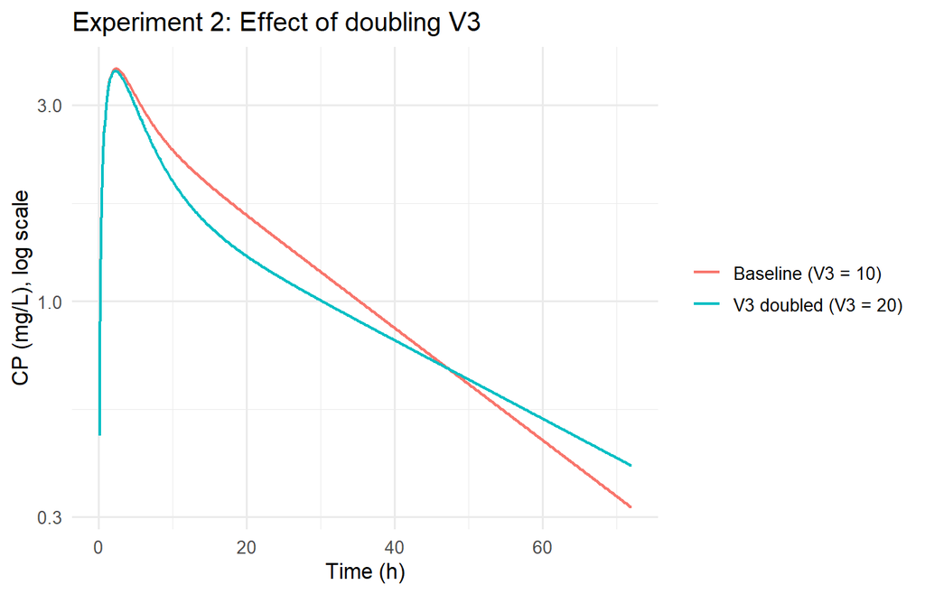

Figure 5. Doubling V3 on semi-log scale. The two curves cross: V3 doubled sits below baseline early, then above it later.

```r
sim_exp2 %>%
  filter(CP > 0) %>%
  ggplot(aes(x = time, y = CP, color = scenario)) +
  geom_line(linewidth = 0.8) +
  scale_y_log10() +
  labs(
    title = "Experiment 2: Effect of doubling V3",
    x = "Time (h)", y = "CP (mg/L), log scale", color = NULL
  ) +
  theme_minimal(base_size = 12)
```

### 4.2.2 Why one parameter moves CP in opposite directions

**What I see:** V3 enters the ODE system only through the inter-compartmental return term (Q/V3) · A_PERIPH. It does not appear in the definition CP = A_CENT / V2. Therefore, its influence on plasma concentration is entirely indirect, mediated through drug redistribution. Doubling V3 halves Q/V3, which slows the return of drug from the peripheral compartment to the central compartment. This single kinetic change has opposite consequences depending on which phase of the profile dominates.

During the distribution phase, the net flow is from central to peripheral compartment. Slowing the return flux reduces the compensating back-flow, increasing the net outward transfer. The result is that more drug is retained in the periphery and CP falls further below baseline.

During the terminal phase, the two compartments have reached quasi-equilibrium and the system behaves approximately as a single pool with effective volume V2 + V3. The peripheral compartment is now a reservoir, and the return flux from peripheral to central is the dominant source of drug sustaining plasma concentration. Slowing that return releases drug more gradually, extending the effective volume from 30 L to 40 L and prolonging the terminal half-life. CP therefore declines more slowly and eventually crosses above baseline.

These are not two separate effects but two faces of one mechanism, the slowed Q/V3 return, operating on different time scales. The crossover point (~45 h) is where the benefit of prolonged release overtakes the cost of early sequestration.

### 4.2.3 Terminal half-life check

A log-linear fit to the terminal segment confirms the late-phase behavior:

```r
data.frame(
  scenario = c("Baseline (V3 = 10)", "V3 doubled (V3 = 20)"),
  terminal_half_life_h = c(
    terminal_thalf(out_baseline),
    terminal_thalf(out_v3)
  ),
  approx_half_life_h = log(2) * c(30, 40) / 1
)
```

```
##               scenario terminal_half_life_h approx_half_life_h
## 1   Baseline (V3 = 10)             22.08453           20.79442
## 2 V3 doubled (V3 = 20)             31.60259           27.72589
```

The estimated terminal half-life increases from ~22 h to ~32 h after doubling V3, confirming that a larger peripheral compartment prolongs the terminal phase. The simple approximation $t_{1/2} \approx \ln 2 \cdot (V_2 + V_3) / CL$ predicts 20.8 h and 27.7 h, which underestimates in both cases. The gap is larger for V3 = 20 (~4 h difference). I suspect this is because the approximation assumes rapid equilibrium between compartments ($Q \gg CL$), and with $Q/CL = 2$ that assumption may not hold well enough. The log-linear regression, which makes no such assumption, is likely the more trustworthy estimate here.

### 4.2.4 AUC conservation check

Changing V3 should not alter AUC₀₋∞: total exposure is governed by $\text{AUC} = F \cdot \text{Dose} / CL$, and neither F, Dose, nor CL changed.

The trapezoidal AUC computed below is AUC to the end of the simulation window, not a true AUC₀₋∞. Therefore, small differences can appear when V3 changes the terminal tail. AUC₀₋∞ would be expected to remain Dose/CL in this linear model.

```r
data.frame(
  scenario = c("Baseline (V3 = 10)", "V3 doubled (V3 = 20)"),
  AUC = c(auc_trap(out_baseline), auc_trap(out_v3))
)
```

```
##               scenario      AUC
## 1   Baseline (V3 = 10) 89.89506
## 2 V3 doubled (V3 = 20) 81.75228
```

### 4.2.5 Note on Cmax insensitivity

Although V3 substantially altered the later concentration profile, its effect on Cmax was minimal. Around Tmax, little drug has yet accumulated in the peripheral compartment, so the return flux (Q/V3) · A_PERIPH remains small regardless of V3. The influence of V3 emerges only later, as peripheral drug accumulation increases and redistribution becomes the dominant process.

## 4.3 Experiment 3: `Q` toward 0 (does pk2 degenerate to pk1?)

If the peripheral compartment is the only thing separating `pk2` from `pk1`, then shutting off the exchange (`Q -> 0`) should make `pk2` behave exactly like `pk1`. This experiment tests that, and the test is quantitative, not visual.

```r
# pk1 for comparison
mod_pk1 <- modlib("pk1")
out_pk1  <- run_single_dose(mod_pk1, dose = 100)

# pk2 with Q -> 0
out_q0 <- mod %>% param(Q = 0.001) %>% run_single_dose(dose = 100)

sim_exp3 <- bind_rows(
  label_run(out_baseline, "pk2 baseline (Q = 2)"),
  label_run(out_q0,       "pk2 with Q -> 0 (Q = 0.001)"),
  label_run(out_pk1,      "pk1 baseline (1-compartment)")
)
```

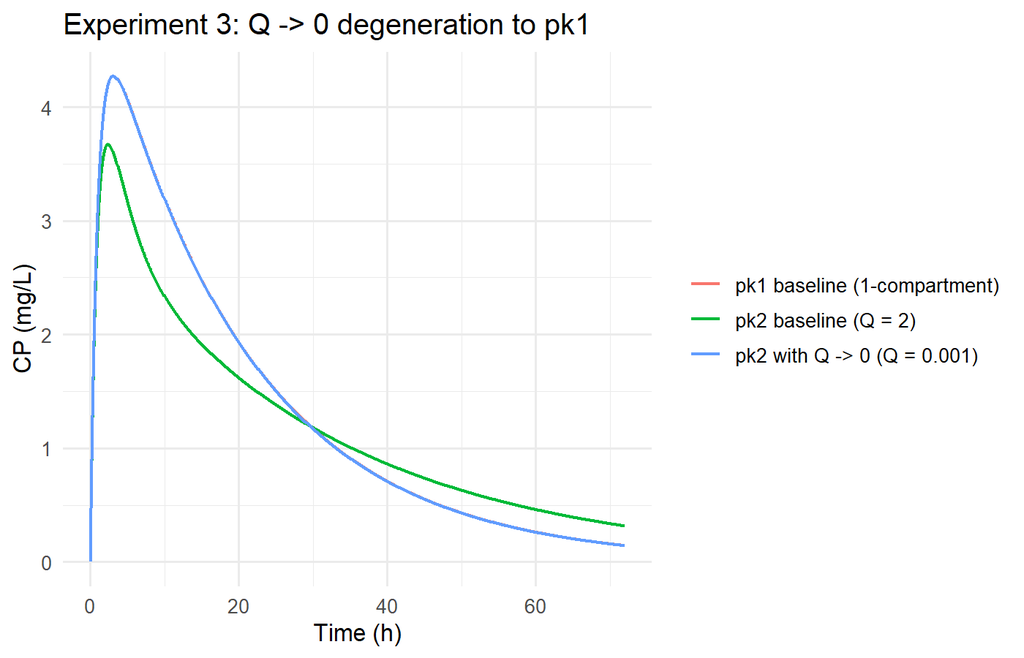

Figure 6. pk2 with Q -> 0 overlaid on pk1. The pk1 curve is not missing; it is hidden underneath the pk2 Q -> 0 curve.

```r
ggplot(sim_exp3, aes(x = time, y = CP, color = scenario)) +
  geom_line(linewidth = 0.8) +
  labs(
    title = "Experiment 3: Q -> 0 degeneration to pk1",
    x = "Time (h)", y = "CP (mg/L)", color = NULL
  ) +
  theme_minimal(base_size = 12)
```

The two curves appear to overlap so completely that only two lines are visible where three were plotted. Rather than trust the eye, quantify the residual between `pk2 (Q -> 0)` and `pk1`:

```r
compare <- out_q0 %>%
  select(time, CP_q0 = CP) %>%
  left_join(out_pk1 %>% select(time, CP_pk1 = CP), by = "time") %>%
  mutate(diff = CP_q0 - CP_pk1)

summary(compare$diff)
```

```
##       Min.    1st Qu.     Median       Mean    3rd Qu.       Max.
## -0.0018334 -0.0016557 -0.0012354 -0.0011953 -0.0007859  0.0000000
```

```r
max(abs(compare$diff))
```

```
## [1] 0.001833374
```

**What I see:** The residuals are uniformly negative and extremely small, indicating that CP under pk2 with Q = 0.001 is only fractionally lower than under pk1. The negative sign is expected: even Q = 0.001 allows a trickle of drug to transfer into the peripheral compartment, reducing the central amount by a negligible amount. Strict equivalence requires Q = 0 exactly, but the residual at Q = 0.001 is well below any measurable precision, confirming the structural degeneration.

This degeneration is also visible directly in the ODE: as `Q -> 0`, both `Q`-dependent terms in the central-compartment equation vanish, leaving

$$\frac{dA_{CENT}}{dt} = K_A \cdot A_{EV} - \frac{CL}{V_2} \cdot A_{CENT},$$

which is exactly the `pk1` central-compartment equation (with `V2 = V`). The peripheral compartment receives nothing and stays empty. So the overlap is not a coincidence; it is structurally guaranteed whenever the carried-over parameters match.

## 4.4 Experiment 4: `Q` toward infinity (rapid-equilibrium limit)

The opposite extreme. If `Q` is very large, the two compartments equilibrate almost instantly, and the system should behave like a single compartment with the combined volume `V2 + V3`.

```r
out_qinf <- mod %>% param(Q = 100) %>% run_single_dose(dose = 100)

sim_exp4 <- bind_rows(
  label_run(out_baseline, "Baseline (Q = 2)"),
  label_run(out_qinf,     "Q -> inf (Q = 100)")
)
```

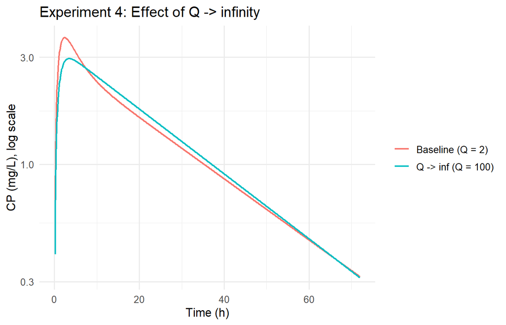

Figure 7. Q -> infinity on semi-log scale. The distribution-phase kink disappears; the terminal slope matches baseline.

```r
sim_exp4 %>%
  filter(CP > 0) %>%
  ggplot(aes(x = time, y = CP, color = scenario)) +
  geom_line(linewidth = 0.8) +
  scale_y_log10() +
  labs(
    title = "Experiment 4: Effect of Q -> infinity",
    x = "Time (h)", y = "CP (mg/L), log scale", color = NULL
  ) +
  theme_minimal(base_size = 12)
```

**What I see:** Compared with the baseline, Cmax under rapid equilibrium is lower and Tmax is slightly delayed. Rapid inter-compartmental exchange causes drug to distribute almost immediately throughout the combined volume V2 + V3, reducing the concentration observed in the central compartment alone.

The distribution-phase kink disappears entirely. Because equilibration between compartments occurs on a time scale much faster than either absorption or elimination, the distribution phase collapses into an imperceptibly short interval. The plasma concentration enters a single log-linear decline immediately after Cmax.

Despite the dramatically different early behavior, both scenarios ultimately converge to the same terminal slope: once the baseline curve also reaches quasi-equilibrium, both systems behave as a single well-mixed pool with effective volume V2 + V3. Q mainly determines how fast the system reaches the terminal phase. In the rapid-equilibrium approximation, the terminal phase is governed mostly by the effective volume and clearance, although the exact hybrid terminal slope can still change slightly with Q.

Putting both extremes of `Q` on one plot shows the full picture: `Q` is a slider between a fully separated two-compartment system and a single well-mixed volume.

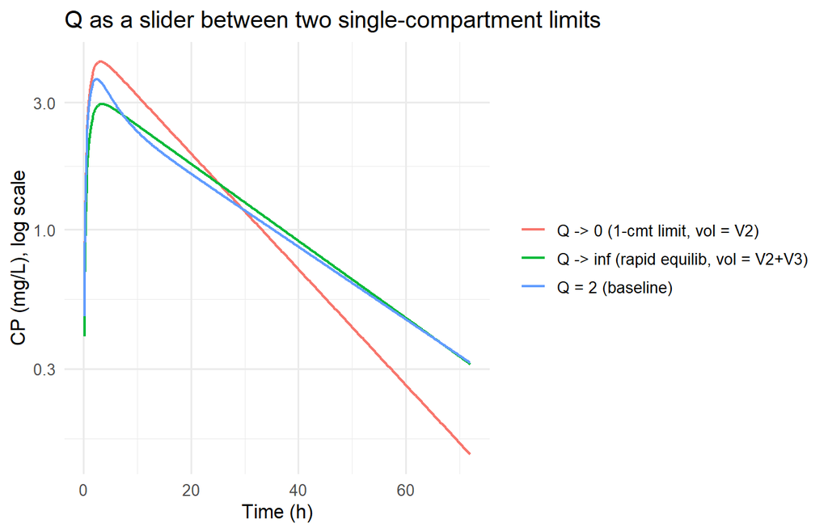

Figure 8. Q as a slider. Q -> 0 recovers the one-compartment limit (effective volume V2); Q -> infinity gives instantaneous equilibrium (effective volume V2 + V3). Both extremes erase the kink, for opposite reasons.

```r
sim_q_slider <- bind_rows(
  label_run(out_q0,       "Q -> 0 (1-cmt limit, vol = V2)"),
  label_run(out_baseline, "Q = 2 (baseline)"),
  label_run(out_qinf,     "Q -> inf (rapid equilib, vol = V2+V3)")
)

sim_q_slider %>%
  filter(CP > 0) %>%
  ggplot(aes(x = time, y = CP, color = scenario)) +
  geom_line(linewidth = 0.8) +
  scale_y_log10() +
  labs(
    title = "Q as a slider between two single-compartment limits",
    x = "Time (h)", y = "CP (mg/L), log scale", color = NULL
  ) +
  theme_minimal(base_size = 12)
```

**What I see:** The two limiting cases both erase the distribution-phase kink, but for opposite reasons. As Q approaches zero, the distribution mode vanishes because the peripheral compartment is kinetically isolated; drug remains in the central compartment, and the effective volume is V2 alone. As Q approaches infinity, the distribution phase occurs almost instantaneously; drug spreads across both compartments before any measurable time elapses, and the effective volume is V2 + V3. Only at intermediate values of Q does the kink appear, because only then is the distribution time scale slow enough to observe but fast enough to matter.

## 4.5 Experiment 5: Double the dose (dose-proportional scaling)

```r
out_dose200 <- run_single_dose(mod, dose = 200)

sim_exp5 <- bind_rows(
  label_run(out_baseline,  "Dose = 100 mg"),
  label_run(out_dose200,   "Dose = 200 mg")
)
```

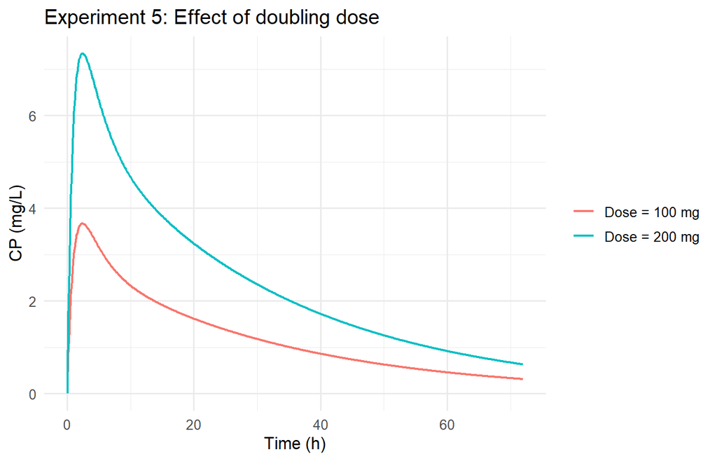

Figure 9. Doubling the dose scales the entire curve by a factor of two; shape, Tmax, and terminal slope are unchanged.

```r
ggplot(sim_exp5, aes(x = time, y = CP, color = scenario)) +
  geom_line(linewidth = 0.8) +
  labs(
    title = "Experiment 5: Effect of doubling dose",
    x = "Time (h)", y = "CP (mg/L)", color = NULL
  ) +
  theme_minimal(base_size = 12)
```

A numeric check that the scaling is exactly proportional:

```r
ratio_check <- out_dose200 %>%
  select(time, CP_200 = CP) %>%
  left_join(out_baseline %>% select(time, CP_100 = CP), by = "time") %>%
  filter(CP_100 > 0.01) %>%
  mutate(ratio = CP_200 / CP_100)

summary(ratio_check$ratio)
```

```
##    Min. 1st Qu.  Median    Mean 3rd Qu.    Max.
##       2       2       2       2       2       2
```

**What I see:** The ratio of the 200 mg to 100 mg concentration is exactly 2.0 at every time point. This confirms dose-proportional scaling: CL, Q, V2, and V3 are all constants (not concentration-dependent), so all elimination and distribution processes are first-order. Doubling the input doubles every output. The two-compartment structure does not change the linearity established in pk1. Exposure is dose-proportional; dose changes the scale of the concentration profile but not the kinetic rate constants governing its shape.

## 4.6 Experiment 6: Multiple dosing (Q12h × 5)

The final experiment repeats the multiple-dose regimen from `pk1`, this time comparing the one- and two-compartment models directly.

```r
mod_pk1 <- modlib("pk1")
mod_pk2 <- mod

out_multi_pk1 <- mod_pk1 %>%
  ev(amt = 100, ii = 12, addl = 4) %>%
  mrgsim(end = 96, delta = 0.1) %>%
  as.data.frame()

out_multi_pk2 <- mod_pk2 %>%
  ev(amt = 100, ii = 12, addl = 4) %>%
  mrgsim(end = 96, delta = 0.1) %>%
  as.data.frame()

sim_exp6 <- bind_rows(
  out_multi_pk1 %>% mutate(model = "pk1"),
  out_multi_pk2 %>% mutate(model = "pk2")
)
```

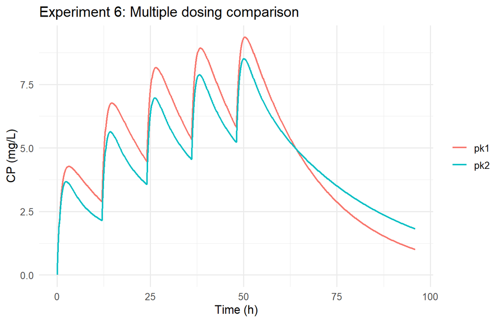

Figure 10. Multiple dosing comparison between pk1 and pk2 under 100 mg Q12h x 5.

```r
ggplot(sim_exp6, aes(x = time, y = CP, color = model)) +
  geom_line(linewidth = 0.8) +
  labs(
    title = "Experiment 6: Multiple dosing comparison",
    x = "Time (h)",
    y = "CP (mg/L)",
    color = NULL
  ) +
  theme_minimal(base_size = 12)
```

### 4.6.1 Cmax / Cmin at steady state

```r
last_dose_time <- 48
tau <- 12

sim_exp6 %>%
  filter(time >= last_dose_time, time <= last_dose_time + tau) %>%
  group_by(model) %>%
  summarise(
    Cmax = max(CP),
    Cmin = min(CP),
    .groups = "drop"
  )
```

```
## # A tibble: 2 × 3
##   model  Cmax  Cmin
##   <chr> <dbl> <dbl>
## 1 pk1    9.35  5.82
## 2 pk2    8.51  5.22
```

### 4.6.2 Fluctuation

```r
last_dose_time <- 48
tau <- 12

sim_exp6 %>%
  filter(time >= last_dose_time, time <= last_dose_time + tau) %>%
  group_by(model) %>%
  summarise(
    fluctuation = max(CP) - min(CP),
    ratio = max(CP) / min(CP),
    .groups = "drop"
  )
```

```
## # A tibble: 2 × 3
##   model fluctuation ratio
##   <chr>       <dbl> <dbl>
## 1 pk1          3.53  1.61
## 2 pk2          3.28  1.63
```

The summary was calculated over the last dosing interval from 48 to 60 h, rather than over the entire post-dose tail. This avoids treating the washout phase as part of the steady-state trough calculation.

**What I see:** Compared with pk1, pk2 exhibits slightly smaller peak-to-trough fluctuation within each dosing interval. Distribution into the peripheral compartment siphons drug away from the central compartment after each dose, reducing peak concentrations. The peripheral compartment also slows the decline between doses by releasing drug back, but under the baseline parameter set this effect is not large enough to raise troughs above pk1. Overall, the concentration profile is modestly dampened: lower peaks, similar troughs, and narrower swings. I can see how this dampening would matter clinically: for drugs with narrow therapeutic windows, the peripheral compartment could reduce the risk of transient supra-therapeutic peaks after each dose.

# 5 Summary: parameter influence matrix

A condensed reference for what each parameter controls in this model.

Table 1. How each parameter shifts the canonical features of the CP curve.

[output not shown]

A few patterns worth noting. Distribution-related parameters (Q and V3) have limited influence on Cmax. Because peak concentration occurs before substantial drug accumulation in the peripheral compartment, these parameters have much smaller effects on Cmax than parameters governing absorption, clearance, or central volume.

Q and V3 play fundamentally different roles. Q is a rate parameter: it governs how quickly the system approaches quasi-equilibrium without substantially altering where that equilibrium sits. V3 is a capacity parameter: it determines how much drug can be stored peripherally and therefore sets the effective distribution volume at later times.

A single parameter can produce opposite effects at different stages of the profile. Increasing V3 lowers CP during distribution (more peripheral sequestration) but raises CP during the terminal phase (larger effective volume, longer half-life). This underscores a general principle: parameter influence should be interpreted through the equations in which a parameter appears, not the compartment label it carries.

The conceptual jump from one to two compartments:

Table 2. What pk2 adds relative to pk1.

| Aspect | pk1 | pk2 |
| --- | --- | --- |
| Compartments | 1 (central only) | 2 (central + peripheral) |
| Decline phases (semi-log) | 1 (single straight line) | 2 (distribution + elimination, with a kink) |
| Effective volume | V | V2 + V3 at quasi-equilibrium |
| New parameters | — | Q (rate), V3 (capacity) |
| Terminal half-life driver | V / CL | ln 2 * (V2 + V3) / CL (approx.) |

The semi-log plot reveals two distinct decline phases, which is the hallmark of a two-compartment system: each kinetically distinguishable compartment contributes its own exponential term to the overall profile.

## 5.1 Clinical relevance

Working through these experiments, I can see how two-compartment kinetics would matter for practical dosing decisions. The rapid post-peak drop during the distribution phase seems directly relevant to loading-dose design, and the dampened peak-to-trough fluctuation in Experiment 6 suggests that ignoring distribution could lead to overly conservative dosing intervals. These are connections I want to explore more concretely as I move toward published clinical PK models in the next project.

# 6 Reflection

The experiment that taught me the most was the V3 sensitivity analysis. I predicted that doubling the peripheral volume would lower plasma concentrations across the entire post-Cmax curve. The simulation proved this half-right: concentrations fell during the distribution phase but crossed above baseline around 45 h and remained higher through the terminal phase. A similar moment occurred in pk1 when the V experiment contradicted my initial prediction. In both cases, the failed prediction was more instructive than a confirmed one, because it forced me back to the equations.

The mechanism, traced in detail in Experiment 2, reduces to a single kinetic change (halving the Q/V3 return rate) whose consequences reverse sign depending on which phase of the profile dominates. Before this project, I tended to interpret parameters by the compartment they belong to (“V3 is a peripheral parameter, so it affects peripheral behavior”). The V3 result taught me to trace where a parameter sits in the governing equations instead.

**Engineering parallel:** This discipline is familiar from my PhD work in finite-element analysis of knee joint models built from statistical shape modeling. A single geometric parameter, such as femoral condyle curvature, could simultaneously affect cartilage contact area, peak contact pressure, and fluid pressurization, with its net effect depending on the loading phase. Intuition about what a “shape parameter” should do was frequently misleading; the only reliable approach was to trace it through the coupled governing equations. The V3 analysis was the same class of problem in a pharmacokinetic setting: a parameter whose influence is indirect, time-dependent, and counterintuitive unless followed through the mathematics.

As these models grow toward full QSP systems with dozens of coupled states and feedback loops, I expect this equation-tracing discipline to become not just useful but necessary.

# 7 Next steps

The next project (`04_pk3_published_model/`) steps away from built-in models and reproduces a published population PK model from the literature, with covariate effects and inter-individual variability. That is the form pharmacometric work actually takes in industry and regulatory practice: not exploring a textbook structure, but fitting and qualifying a model against real data and reported parameter estimates.